# 2mode examples

CInguaggiato

Thursday, July 18, 2014

### Synopsis

This document deals with **two mode networks** and relates with the two-mode networks when transformed in one-mode undirected networks.

Specifically it considers cooperative innovation projects, where several subjects costitute temporary agency to make research projects.  
The participating organizations connected to each other through co-membership in innovation projects create networks.

The document argues that both the brokerage index and the intercohesive factor are related with the common participation in projects.

The approach proposed by Tore Opsahl (Opsahl and Panzarasa, 2009) is applied to get a better understanding of possible solutions.

### Empirical data

The dataset relates with the projects submitted in a call for proposal issued by Regione Piemonte in 2010. The call addresses “Life Science innovation projects”.

9 are the projects submitted.  
78 the subjects who participated.  
The list of participants per project follows:

```r
biotech<-read.table("~/GitHub/2mode/data/biotech.txt",sep=";",
                  header=T, stringsAsFactors = FALSE)
str(biotech)
```

```
## 'data.frame':    94 obs. of  2 variables:
##  $ sbj: chr  "AAA" "Aethia" "Apavadis" "Apereserce" ...
##  $ prj: chr  "PIMDMT" "PISTEM" "DRUIDI" "ATIVE" ...
```

```r
myprj<-unique(biotech$prj)

# prjsbj represents sbj for each prj

prjsbj<-sapply(myprj, function(x) biotech$sbj[biotech$prj==x])
```

12 subjects participate in more than one project

```r
sbj2<-table(biotech$sbj)[table(biotech$sbj)>1]
names(sbj2)
```

```
##  [1] "AsuMolinette" "FPRC"         "IM3D"         "INRIM"
##  [5] "Micro_la"     "RBM"          "Techfab"      "UNI_PI"
##  [9] "UniPmn"       "UNITO"        "UniTO_CMBC"   "UniTO_DSCB"
```

#### 2mode and 1mode networks

A basic plot shows projects (in red), participants (in gold). The 12 subjects in more than one project are brown.

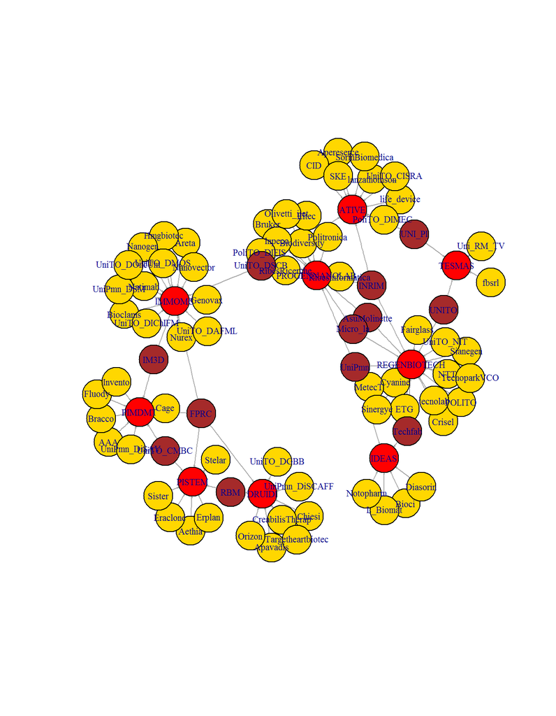

```r
library (igraph)

gbiotech <- graph.data.frame(biotech)

# set prj type <- TRUE
V(gbiotech)$type <- V(gbiotech)$name %in% biotech[,1]

v_col<-rep("gold",87)

v_col[!V(gbiotech)$type]<-c("red")
v_col[V(gbiotech)$name %in% names(sbj2)]<-c("brown")


plot.igraph(gbiotech, layout=layout.fruchterman.reingold, edge.arrow.size=0.1,
            vertex.label.cex=.7,vertex.color=v_col)
```

Then from a 2 mode network has been created the network of subjects and the network of projects.

A basic plot shows the participants divided by project. The 12 subjects in more than one project are white.

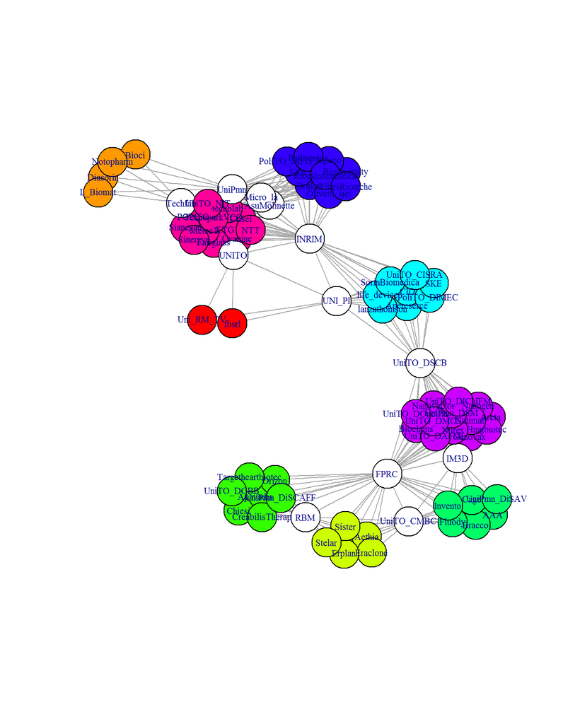

```r
nnbio<-bipartite.projection(gbiotech)


snbio<-nnbio$proj2
pnbio<-nnbio$proj1

myclique<-maximal.cliques(snbio)
myclique_list<-sapply(myclique, function(x) V(snbio)$name[x])

myblocks=length(myclique)
mycolors<-rainbow(myblocks)
v_col<-rep("white",78)


j<-0
for (i in 1:myblocks){
  j<-j+1
  v_col[myclique[[i]] ]<- mycolors[j]
}
v_col[V(snbio)$name %in% names(sbj2)]<-c("white")

co<-layout.fruchterman.reingold(snbio)
plot.igraph(snbio, layout=co, edge.arrow.size=0.1,
            vertex.label.cex=.7,vertex.color=v_col,)
```

#### Clustering coefficient

A subject is considered as a broker when its transitivity is <1 and a nonbroker =1.

```r
# clustering coefficient
tt<-transitivity (snbio,type=c("local" ))


V(snbio)$name[tt<1]
```

```
##  [1] "AsuMolinette" "FPRC"         "IM3D"         "INRIM"
##  [5] "Micro_la"     "RBM"          "Techfab"      "UNI_PI"
##  [9] "UniPmn"       "UNITO"        "UniTO_CMBC"   "UniTO_DSCB"
```

The 12 subjects with transitivity <1 are the **same 12 subjects** in more than one project.

```r
f<-list ()

for (i in names (prjsbj) ) {

  for (j in names (prjsbj) ) {

    if ( i != j) {
              if (mean(prjsbj[[j]]  %in% prjsbj[[i]]) >0) {
            f[[i]][[j]]<- prjsbj[[i]]  %in% prjsbj[[j]]
        }
    }
    }
 }
ff<-list ()

for (i in names (prjsbj)) {

    ff[[i]]<-sapply( f[[i]], function(x) sum(x) )
}

table(unlist(ff))
```

```
##
##  1  2  4
## 18  8  2
```

#### Clique percolation

I tried to run the clique percolation algorithm developed by Palla et al. (2004) as it’s implemented in R language and riported in [Community Detection In R](http://igraph.wikidot.com/community-detection-in-r) with **k=3**. 3 is equal to the number of subjects in the smallest project minus 1.

```r
# clique.community FUNCTION ##############

clique.community <- function(graph, k) {
  clq <- cliques(graph, min=k, max=k)
  edges <- c()
  for (i in seq_along(clq)) {
    for (j in seq_along(clq)) {
      if ( length(unique(c(clq[[i]], clq[[j]]))) == k+1 ) {
        edges <- c(edges, c(i,j))
      }
    }
  }
  clq.graph <- simplify(graph(edges))
  V(clq.graph)$name <- seq_len(vcount(clq.graph))
  comps <- decompose.graph(clq.graph)

  lapply(comps, function(x) {
    unique(unlist(clq[ V(x)$name ]))
  })
}

cli_com3<-clique.community (snbio,3)
lcli3<-length(cli_com3)

# sapply(cli_com3, function (x) V(snbio)$name[x])
```

In this case **2** communities are the results of the computation. It comprises ALL subjects, as shown in the following plot.

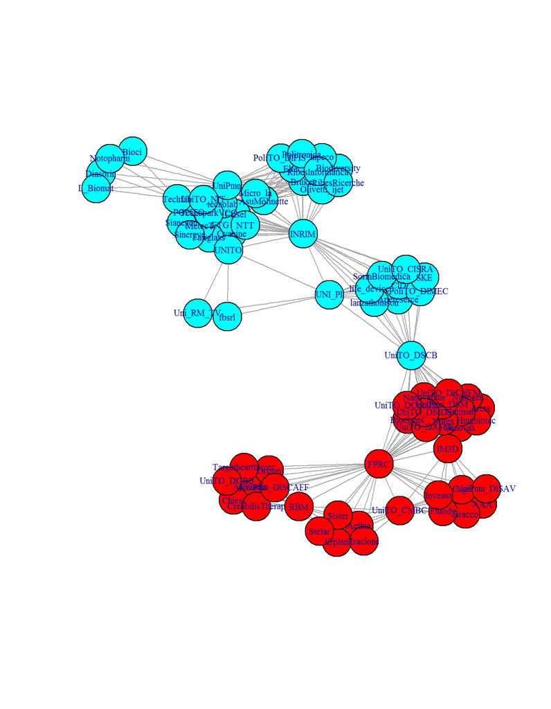

```r
blockcpm=length(cli_com3)
mycolors<-rainbow(blockcpm)
v_col<-rep("white",78)


j<-0
for (i in 1:blockcpm){
    j<-j+1
    v_col[cli_com3[[i]] ]<- mycolors[j]
}
#v_col[V(snbio)$name %in% names(sbj2)]<-c("white")

plot.igraph(snbio, layout=co, edge.arrow.size=0.1,
            vertex.label.cex=.7,vertex.color=v_col)
```

Running the function with **k=4** result is completely different, as shown in the following plot.

```r
cli_com4<-clique.community (snbio,4)
lcli4<-length(cli_com4)

# sapply(cli_com4, function (x) V(snbio)$name[x])
```

In this case **8** communities are the results of the computation.

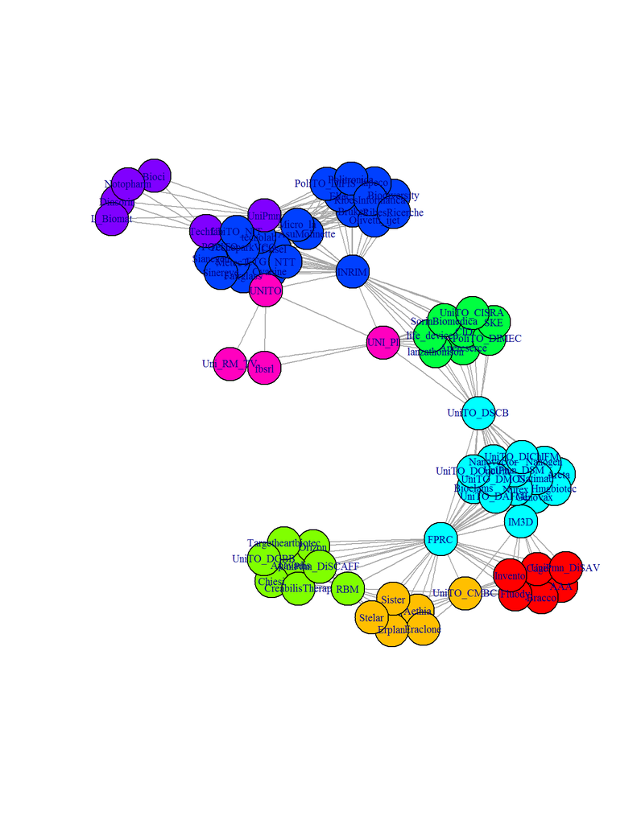

```r
blockcpm=length(cli_com4)
mycolors<-rainbow(blockcpm)
v_col<-rep("white",78)


j<-0
for (i in 1:blockcpm){
    j<-j+1
    v_col[cli_com4[[i]] ]<- mycolors[j]
}

plot.igraph(snbio, layout=co, edge.arrow.size=0.1,
            vertex.label.cex=.7,vertex.color=v_col)
```

#### Clustering in Two-mode Networks

Finally I run the clustering coefficient proposed in [Clustering in Two-mode Networks](http://toreopsahl.com/tnet/two-mode-networks/clustering) by Tore Opsahl (Opsahl and Panzarasa, 2009) to check if same results holds also for this approach.

A Rpackage is available in order to compute several clustering coefficients directly on 2mode network.

```r
library (tnet)
```

```
## tnet: Analysis of Weighted, Two-mode, and Longitudinal networks.
## Type ?tnet for help.
```

```r
biotechx <- as.tnet(biotech, type="binary two-mode tnet")
str(biotechx)

pippo<-biotechx$i
biotechx$i<-as.integer(biotechx$i)
biotechx$p<-as.integer(biotechx$p)+100
#str(biotechx)


# Calculate the reinforcement coefficient (Robins and Alexander, 2004)
reinforcement_tm(biotechx)

# Calculate the global coefficient (Opsahl, 2012)
clustering_tm(biotech)

# Calculate the local coefficient (Opsahl, 2012)
clu_loc<-clustering_local_tm(biotechx)
clu_loc

clu_loc[order(clu_loc$lc),  ]

zz<-clu_loc$node[!is.na(clu_loc$lc)]
```

[output not shown]

Taking the results local coefficient (Opsahl, 2012) I print out subjects with a output different from *NaN*.

The 12 subjects with significant coefficient are the **same 12 subjects** in more than one project.

```r
levels(pippo)[zz]
```

```
##  [1] "AsuMolinette" "FPRC"         "IM3D"         "INRIM"
##  [5] "Micro_la"     "RBM"          "Techfab"      "UNI_PI"
##  [9] "UniPmn"       "UNITO"        "UniTO_CMBC"   "UniTO_DSCB"
```

### Conclusions

Basic concern about two-mode networks when transformed in one-mode undirected networks relates with meaning of clustering and intercohesive factor.

As shown in the document, networks in which the participating organizations are connected to each other through co-membership in innovation projects, strongly induce both the brokerage index and the intercohesive factor **by common participation in projects**.

The brokerage index strictly relates with number of projects participated while the intercohesive factor relates with the projects participated together.

The approach proposed by Tore Opsahl (Opsahl and Panzarasa, 2009) follows same line of understanding.